# Linear Regression & Residual Plots

#### Linear Regression

A residual plot is a graph in which the residuals are displayed on the y axis and the independent variable is displayed on the x-axis. A linear regression model is appropriate for the data if the dots in a residual plot are randomly distributed across the horizontal axis.

Method 1: Using the plot_regress_exog() plot_regress_exog(): Compare the regression findings to one regressor.

```python
import numpy as np
import pandas as pd
import matplotlib.pyplot as plt
import statsmodels.api as sm
from statsmodels.formula.api import ols
```

```python
# reading the csv file
data = pd.read_csv('C:/Users/pn_kumar/Downloads/headbrain3.csv')
```

```python
data.describe()
```

|  | Unnamed: 0 | index | Head_size | Brain_weight |
| --- | --- | --- | --- | --- |
| count | 101.000000 | 101.000000 | 101.000000 | 101.000000 |
| mean | 50.000000 | 50.000000 | 3813.386139 | 1337.485149 |
| std | 29.300171 | 29.300171 | 333.896929 | 109.739110 |
| min | 0.000000 | 0.000000 | 3095.000000 | 1120.000000 |
| 25% | 25.000000 | 25.000000 | 3527.000000 | 1250.000000 |
| 50% | 50.000000 | 50.000000 | 3814.000000 | 1335.000000 |
| 75% | 75.000000 | 75.000000 | 4034.000000 | 1405.000000 |
| max | 100.000000 | 100.000000 | 4747.000000 | 1635.000000 |

```python
data.head(3)
```

|  | Unnamed: 0 | index | Head_size | Brain_weight |
| --- | --- | --- | --- | --- |
| 0 | 0 | 0 | 4512 | 1530 |
| 1 | 1 | 1 | 3738 | 1297 |
| 2 | 2 | 2 | 4261 | 1335 |

```python
# fit simple linear regression model
linear_model = ols('Brain_weight ~ Head_size',
                   data=data).fit()
```

```python
# display model summary
print(linear_model.summary())
```

```
                            OLS Regression Results
==============================================================================
Dep. Variable:           Brain_weight   R-squared:                       0.516
Model:                            OLS   Adj. R-squared:                  0.511
Method:                 Least Squares   F-statistic:                     105.4
Date:                Mon, 26 Dec 2022   Prob (F-statistic):           2.85e-17
Time:                        10:37:11   Log-Likelihood:                -580.70
No. Observations:                 101   AIC:                             1165.
Df Residuals:                      99   BIC:                             1171.
Df Model:                           1
Covariance Type:            nonrobust
==============================================================================
                 coef    std err          t      P>|t|      [0.025      0.975]
------------------------------------------------------------------------------
Intercept    437.4384     87.990      4.971      0.000     262.847     612.030
Head_size      0.2360      0.023     10.268      0.000       0.190       0.282
==============================================================================
Omnibus:                        1.314   Durbin-Watson:                   2.023
Prob(Omnibus):                  0.518   Jarque-Bera (JB):                1.019
Skew:                           0.244   Prob(JB):                        0.601
Kurtosis:                       3.061   Cond. No.                     4.41e+04
==============================================================================

Warnings:
[1] Standard Errors assume that the covariance matrix of the errors is correctly specified.
[2] The condition number is large, 4.41e+04. This might indicate that there are
strong multicollinearity or other numerical problems.
```

```python
# modify figure size
fig = plt.figure(figsize=(14, 8))
```

```python
# creating regression plots
fig = sm.graphics.plot_regress_exog(linear_model,
                                    'Head_size',
                                    fig=fig)
```

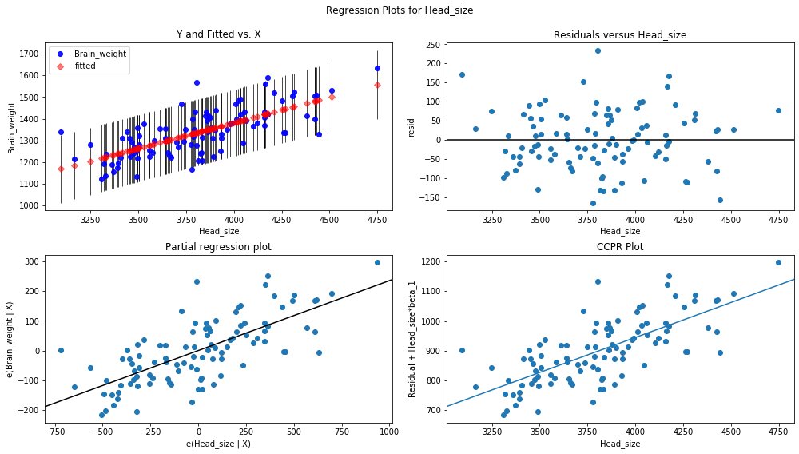

```python
fig
```

#### Output:

We can see that the points are plotted randomly spread or scattered. points or residuals are scattered around the ‘0’ line, there is no pattern, and points are not based on one side so there’s no problem of heteroscedasticity. with the predictor variable ‘Head_size’ there’s no heteroscedasticity.

#### Using seaborn.residplot()

seaborn.residplot(): This function will regress y on x and then plot the residuals as a scatterplot. You can fit a lowess smoother to the residual plot as an option, which can aid in detecting whether the residuals have structure. Parameters: x : column name of the independent variable (predictor) or a vector. y: column name of the dependent variable(response) or a vector. data: optional parameter. dataframe lowess: by default it’s false.

```python
import seaborn as sns
```

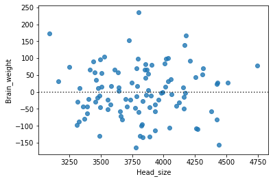

```python
sns.residplot(x='Head_size', y='Brain_weight', data=data)
plt.show()
```

Output:

We can see that the points are plotted in a randomly spread, there is no pattern and points are not based on one side so there’s no problem of heteroscedasticity.

#### Multiple linear regression:

In multiple linear regression, we have more than independent variables or predictor variables and one dependent variable. The code is similar to linear regression except that we have to make this change in the ols() method.

```python
# reading the csv file
data2 = pd.read_csv('C:/Users/pn_kumar/Downloads/homeprices.csv')
```

```python
data2.head()
```

|  | area | bedrooms | age | price |
| --- | --- | --- | --- | --- |
| 0 | 2600 | 3 | 20 | 550000 |
| 1 | 3000 | 4 | 15 | 565000 |
| 2 | 3200 | 3 | 18 | 610000 |
| 3 | 3600 | 3 | 30 | 595000 |
| 4 | 4000 | 5 | 8 | 760000 |

```python
# fit multi linear regression model
multi_model = ols('price ~ area + bedrooms', data=data2).fit()
```

```python
# display model summary
print(multi_model.summary())
```

```
                            OLS Regression Results
==============================================================================
Dep. Variable:                  price   R-squared:                       0.931
Model:                            OLS   Adj. R-squared:                  0.886
Method:                 Least Squares   F-statistic:                     20.39
Date:                Mon, 26 Dec 2022   Prob (F-statistic):             0.0179
Time:                        10:39:14   Log-Likelihood:                -69.526
No. Observations:                   6   AIC:                             145.1
Df Residuals:                       3   BIC:                             144.4
Df Model:                           2
Covariance Type:            nonrobust
==============================================================================
                 coef    std err          t      P>|t|      [0.025      0.975]
------------------------------------------------------------------------------
Intercept   1.461e+05   1.02e+05      1.437      0.246   -1.77e+05     4.7e+05
area          94.0980     42.626      2.208      0.114     -41.557     229.753
bedrooms    4.519e+04   1.98e+04      2.281      0.107   -1.79e+04    1.08e+05
==============================================================================
Omnibus:                          nan   Durbin-Watson:                   3.396
Prob(Omnibus):                    nan   Jarque-Bera (JB):                0.733
Skew:                          -0.629   Prob(JB):                        0.693
Kurtosis:                       1.837   Cond. No.                     2.34e+04
==============================================================================

Warnings:
[1] Standard Errors assume that the covariance matrix of the errors is correctly specified.
[2] The condition number is large, 2.34e+04. This might indicate that there are
strong multicollinearity or other numerical problems.
```

```python
# modify figure size
fig = plt.figure(figsize=(14, 8))
```

```python
# creating regression plots
fig = sm.graphics.plot_regress_exog(multi_model, 'area', fig=fig)
```

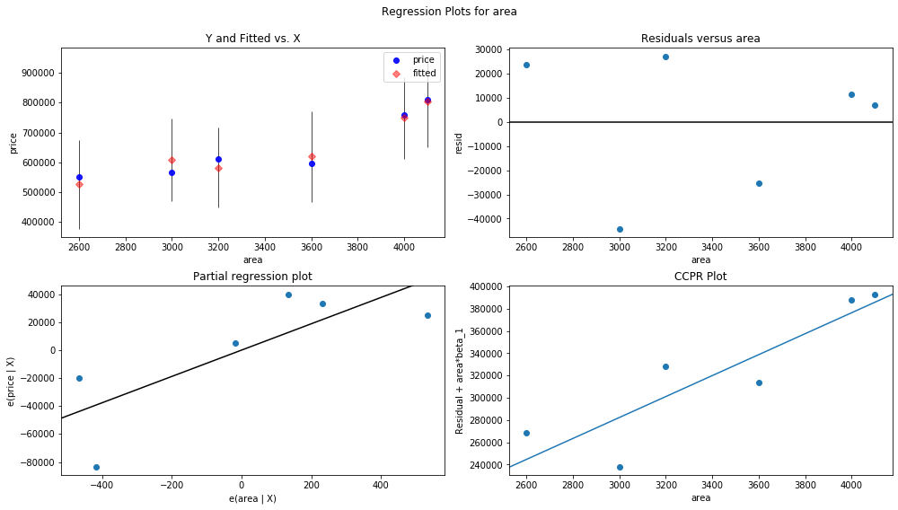

```python
fig
```

We can see that the points are plotted randomly spread or scattered. points or residuals are scattered around the ‘0’ line, there is no pattern, and points are not based on one side so there’s no problem of heteroscedasticity. With the predictor variable ‘area’ there’s no heteroscedasticity.